# Risk Factor Analysis

## Outcome Variable

**Outcome Variable:** ever_wasted

## Predictor Variables

**Intervention Variable:** perdiar24

**Adjustment Set:**

- arm
- sex
- W_mage
- meducyrs
- feducyrs
- hhwealth_quart
- hfoodsec
- hdlvry
- W_birthwt
- W_birthlen
- single
- W_nrooms
- month
- brthmon
- impfloor
- impsan
- safeh20
- delta_W_mage
- delta_meducyrs
- delta_feducyrs
- delta_hhwealth_quart
- delta_hfoodsec
- delta_hdlvry
- delta_W_birthwt
- delta_W_birthlen
- delta_single
- delta_W_nrooms
- delta_month
- delta_brthmon
- delta_impfloor
- delta_impsan
- delta_safeh20

## Stratifying Variables

The analysis was stratified on these variable(s):

- agecat
- studyid
- country

## Data Summary

| agecat | studyid | country | perdiar24 | ever_wasted | n_cell | n |
| --- | --- | --- | --- | --- | --- | --- |
| 0-24 months (no birth wast) | CMIN | BANGLADESH | 0% | 0 | 8 | 268 |
| 0-24 months (no birth wast) | CMIN | BANGLADESH | 0% | 1 | 1 | 268 |
| 0-24 months (no birth wast) | CMIN | BANGLADESH | (0%, 5%] | 0 | 69 | 268 |
| 0-24 months (no birth wast) | CMIN | BANGLADESH | (0%, 5%] | 1 | 51 | 268 |
| 0-24 months (no birth wast) | CMIN | BANGLADESH | >5% | 0 | 76 | 268 |
| 0-24 months (no birth wast) | CMIN | BANGLADESH | >5% | 1 | 63 | 268 |
| 0-24 months (no birth wast) | CONTENT | PERU | 0% | 0 | 6 | 215 |
| 0-24 months (no birth wast) | CONTENT | PERU | 0% | 1 | 0 | 215 |
| 0-24 months (no birth wast) | CONTENT | PERU | (0%, 5%] | 0 | 139 | 215 |
| 0-24 months (no birth wast) | CONTENT | PERU | (0%, 5%] | 1 | 3 | 215 |
| 0-24 months (no birth wast) | CONTENT | PERU | >5% | 0 | 66 | 215 |
| 0-24 months (no birth wast) | CONTENT | PERU | >5% | 1 | 1 | 215 |
| 0-24 months (no birth wast) | EE | PAKISTAN | 0% | 0 | 123 | 377 |
| 0-24 months (no birth wast) | EE | PAKISTAN | 0% | 1 | 137 | 377 |
| 0-24 months (no birth wast) | EE | PAKISTAN | (0%, 5%] | 0 | 51 | 377 |
| 0-24 months (no birth wast) | EE | PAKISTAN | (0%, 5%] | 1 | 66 | 377 |
| 0-24 months (no birth wast) | EE | PAKISTAN | >5% | 0 | 0 | 377 |
| 0-24 months (no birth wast) | EE | PAKISTAN | >5% | 1 | 0 | 377 |
| 0-24 months (no birth wast) | Guatemala BSC | GUATEMALA | 0% | 0 | 30 | 307 |
| 0-24 months (no birth wast) | Guatemala BSC | GUATEMALA | 0% | 1 | 2 | 307 |
| 0-24 months (no birth wast) | Guatemala BSC | GUATEMALA | (0%, 5%] | 0 | 63 | 307 |
| 0-24 months (no birth wast) | Guatemala BSC | GUATEMALA | (0%, 5%] | 1 | 8 | 307 |
| 0-24 months (no birth wast) | Guatemala BSC | GUATEMALA | >5% | 0 | 188 | 307 |
| 0-24 months (no birth wast) | Guatemala BSC | GUATEMALA | >5% | 1 | 16 | 307 |
| 0-24 months (no birth wast) | iLiNS-Zinc | BURKINA FASO | 0% | 0 | 307 | 2348 |
| 0-24 months (no birth wast) | iLiNS-Zinc | BURKINA FASO | 0% | 1 | 22 | 2348 |
| 0-24 months (no birth wast) | iLiNS-Zinc | BURKINA FASO | (0%, 5%] | 0 | 1169 | 2348 |
| 0-24 months (no birth wast) | iLiNS-Zinc | BURKINA FASO | (0%, 5%] | 1 | 114 | 2348 |
| 0-24 months (no birth wast) | iLiNS-Zinc | BURKINA FASO | >5% | 0 | 651 | 2348 |
| 0-24 months (no birth wast) | iLiNS-Zinc | BURKINA FASO | >5% | 1 | 85 | 2348 |

[output cut: 270 more lines]

The following strata were considered:

- agecat: 0-24 months (no birth wast), studyid: CMIN, country: BANGLADESH
- agecat: 0-24 months (no birth wast), studyid: CONTENT, country: PERU
- agecat: 0-24 months (no birth wast), studyid: EE, country: PAKISTAN
- agecat: 0-24 months (no birth wast), studyid: Guatemala BSC, country: GUATEMALA
- agecat: 0-24 months (no birth wast), studyid: iLiNS-Zinc, country: BURKINA FASO
- agecat: 0-24 months (no birth wast), studyid: JiVitA-4, country: BANGLADESH
- agecat: 0-24 months (no birth wast), studyid: MAL-ED, country: BANGLADESH
- agecat: 0-24 months (no birth wast), studyid: MAL-ED, country: BRAZIL
- agecat: 0-24 months (no birth wast), studyid: MAL-ED, country: INDIA
- agecat: 0-24 months (no birth wast), studyid: MAL-ED, country: NEPAL
- agecat: 0-24 months (no birth wast), studyid: MAL-ED, country: PERU
- agecat: 0-24 months (no birth wast), studyid: MAL-ED, country: SOUTH AFRICA
- agecat: 0-24 months (no birth wast), studyid: MAL-ED, country: TANZANIA, UNITED REPUBLIC OF
- agecat: 0-24 months (no birth wast), studyid: NIH-Birth, country: BANGLADESH
- agecat: 0-24 months (no birth wast), studyid: NIH-Crypto, country: BANGLADESH
- agecat: 0-24 months (no birth wast), studyid: PROVIDE, country: BANGLADESH
- agecat: 0-24 months (no birth wast), studyid: SAS-FoodSuppl, country: INDIA
- agecat: 0-6 months (no birth wast), studyid: CMIN, country: BANGLADESH
- agecat: 0-6 months (no birth wast), studyid: CONTENT, country: PERU
- agecat: 0-6 months (no birth wast), studyid: EE, country: PAKISTAN
- agecat: 0-6 months (no birth wast), studyid: Guatemala BSC, country: GUATEMALA
- agecat: 0-6 months (no birth wast), studyid: JiVitA-4, country: BANGLADESH
- agecat: 0-6 months (no birth wast), studyid: MAL-ED, country: BANGLADESH
- agecat: 0-6 months (no birth wast), studyid: MAL-ED, country: BRAZIL
- agecat: 0-6 months (no birth wast), studyid: MAL-ED, country: INDIA
- agecat: 0-6 months (no birth wast), studyid: MAL-ED, country: NEPAL
- agecat: 0-6 months (no birth wast), studyid: MAL-ED, country: PERU
- agecat: 0-6 months (no birth wast), studyid: MAL-ED, country: SOUTH AFRICA
- agecat: 0-6 months (no birth wast), studyid: MAL-ED, country: TANZANIA, UNITED REPUBLIC OF
- agecat: 0-6 months (no birth wast), studyid: NIH-Birth, country: BANGLADESH
- agecat: 0-6 months (no birth wast), studyid: NIH-Crypto, country: BANGLADESH
- agecat: 0-6 months (no birth wast), studyid: PROVIDE, country: BANGLADESH
- agecat: 0-6 months (no birth wast), studyid: SAS-FoodSuppl, country: INDIA
- agecat: 6-24 months, studyid: CMIN, country: BANGLADESH
- agecat: 6-24 months, studyid: CONTENT, country: PERU
- agecat: 6-24 months, studyid: EE, country: PAKISTAN
- agecat: 6-24 months, studyid: Guatemala BSC, country: GUATEMALA
- agecat: 6-24 months, studyid: iLiNS-Zinc, country: BURKINA FASO
- agecat: 6-24 months, studyid: JiVitA-4, country: BANGLADESH
- agecat: 6-24 months, studyid: MAL-ED, country: BANGLADESH
- agecat: 6-24 months, studyid: MAL-ED, country: BRAZIL
- agecat: 6-24 months, studyid: MAL-ED, country: INDIA
- agecat: 6-24 months, studyid: MAL-ED, country: NEPAL
- agecat: 6-24 months, studyid: MAL-ED, country: PERU
- agecat: 6-24 months, studyid: MAL-ED, country: SOUTH AFRICA
- agecat: 6-24 months, studyid: MAL-ED, country: TANZANIA, UNITED REPUBLIC OF
- agecat: 6-24 months, studyid: NIH-Birth, country: BANGLADESH
- agecat: 6-24 months, studyid: NIH-Crypto, country: BANGLADESH
- agecat: 6-24 months, studyid: PROVIDE, country: BANGLADESH
- agecat: 6-24 months, studyid: SAS-FoodSuppl, country: INDIA

### Dropped Strata

Some strata were dropped due to rare outcomes:

- agecat: 0-24 months (no birth wast), studyid: CMIN, country: BANGLADESH
- agecat: 0-24 months (no birth wast), studyid: CONTENT, country: PERU
- agecat: 0-24 months (no birth wast), studyid: EE, country: PAKISTAN
- agecat: 0-24 months (no birth wast), studyid: Guatemala BSC, country: GUATEMALA
- agecat: 0-24 months (no birth wast), studyid: MAL-ED, country: BANGLADESH
- agecat: 0-24 months (no birth wast), studyid: MAL-ED, country: BRAZIL
- agecat: 0-24 months (no birth wast), studyid: MAL-ED, country: INDIA
- agecat: 0-24 months (no birth wast), studyid: MAL-ED, country: NEPAL
- agecat: 0-24 months (no birth wast), studyid: MAL-ED, country: PERU
- agecat: 0-24 months (no birth wast), studyid: MAL-ED, country: SOUTH AFRICA
- agecat: 0-24 months (no birth wast), studyid: MAL-ED, country: TANZANIA, UNITED REPUBLIC OF
- agecat: 0-24 months (no birth wast), studyid: NIH-Birth, country: BANGLADESH
- agecat: 0-24 months (no birth wast), studyid: PROVIDE, country: BANGLADESH
- agecat: 0-6 months (no birth wast), studyid: CMIN, country: BANGLADESH
- agecat: 0-6 months (no birth wast), studyid: CONTENT, country: PERU
- agecat: 0-6 months (no birth wast), studyid: EE, country: PAKISTAN
- agecat: 0-6 months (no birth wast), studyid: Guatemala BSC, country: GUATEMALA
- agecat: 0-6 months (no birth wast), studyid: JiVitA-4, country: BANGLADESH
- agecat: 0-6 months (no birth wast), studyid: MAL-ED, country: BANGLADESH
- agecat: 0-6 months (no birth wast), studyid: MAL-ED, country: BRAZIL
- agecat: 0-6 months (no birth wast), studyid: MAL-ED, country: INDIA
- agecat: 0-6 months (no birth wast), studyid: MAL-ED, country: NEPAL
- agecat: 0-6 months (no birth wast), studyid: MAL-ED, country: PERU
- agecat: 0-6 months (no birth wast), studyid: MAL-ED, country: SOUTH AFRICA
- agecat: 0-6 months (no birth wast), studyid: MAL-ED, country: TANZANIA, UNITED REPUBLIC OF
- agecat: 0-6 months (no birth wast), studyid: NIH-Birth, country: BANGLADESH
- agecat: 0-6 months (no birth wast), studyid: NIH-Crypto, country: BANGLADESH
- agecat: 0-6 months (no birth wast), studyid: PROVIDE, country: BANGLADESH
- agecat: 0-6 months (no birth wast), studyid: SAS-FoodSuppl, country: INDIA
- agecat: 6-24 months, studyid: CMIN, country: BANGLADESH
- agecat: 6-24 months, studyid: CONTENT, country: PERU
- agecat: 6-24 months, studyid: EE, country: PAKISTAN
- agecat: 6-24 months, studyid: Guatemala BSC, country: GUATEMALA
- agecat: 6-24 months, studyid: MAL-ED, country: BANGLADESH
- agecat: 6-24 months, studyid: MAL-ED, country: BRAZIL
- agecat: 6-24 months, studyid: MAL-ED, country: INDIA
- agecat: 6-24 months, studyid: MAL-ED, country: NEPAL
- agecat: 6-24 months, studyid: MAL-ED, country: PERU
- agecat: 6-24 months, studyid: MAL-ED, country: SOUTH AFRICA
- agecat: 6-24 months, studyid: MAL-ED, country: TANZANIA, UNITED REPUBLIC OF
- agecat: 6-24 months, studyid: NIH-Birth, country: BANGLADESH
- agecat: 6-24 months, studyid: PROVIDE, country: BANGLADESH

## Methods Detail

We’re interested in the causal parameters $E[Y_a]$ for all values of $a \in \mathcal{A}$. These parameters represent the mean outcome if, possibly contrary to fact, we intervened to set all units to have $A=a$. Under the randomization and positivity assumptions, these are identified by the statistical parameters $\psi_a=E_W[E_{Y|A,W}(Y|A=a,W)]$. In addition, we’re interested in the mean of $Y$, $E[Y]$ under no intervention (the observed mean). We will estimate these parameters by using SuperLearner to fit the relevant likelihood factors – $E_{Y|A,W}(Y|A=a,W)$ and $p(A=a|W)$, and then updating our likelihood fit using a joint TMLE.

For unadjusted analyses ($W=\{\}$), initial likelihoods were estimated using Lrnr_glm to estimate the simple $E(Y|A)$ and Lrnr_mean to estimate $p(A)$. For adjusted analyses, a small library containing Lrnr_glmnet, Lrnr_xgboost, and Lrnr_mean was used.

Having estimated these parameters, we will then use the delta method to estimate relative risks and attributable risks relative to a prespecified baseline level of $A$.

# Results Detail

## Results Plots

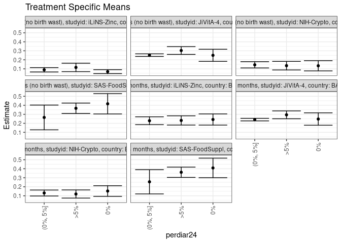

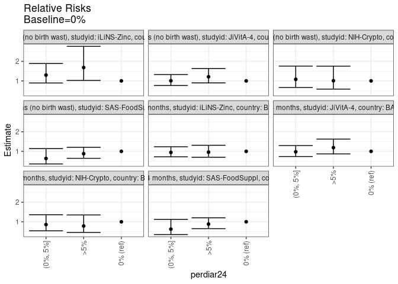

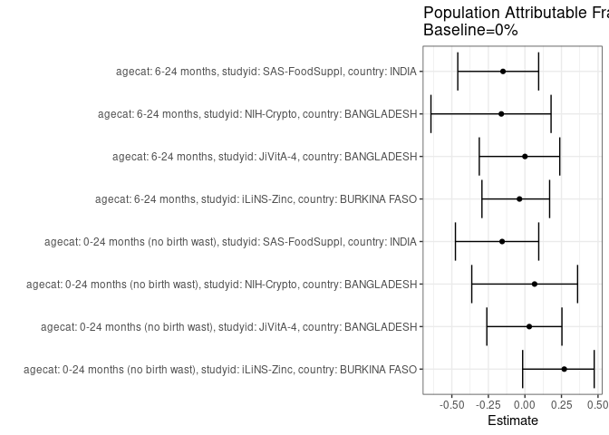

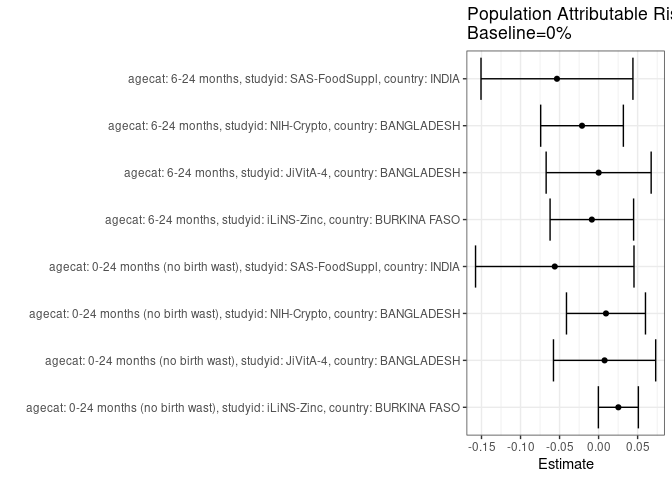

## Results Table

### Parameter: TSM

| agecat | studyid | country | intervention_level | baseline_level | estimate | ci_lower | ci_upper |
| --- | --- | --- | --- | --- | --- | --- | --- |
| 0-24 months (no birth wast) | iLiNS-Zinc | BURKINA FASO | 0% | NA | 0.0687889 | 0.0470212 | 0.0905565 |
| 0-24 months (no birth wast) | iLiNS-Zinc | BURKINA FASO | (0%, 5%] | NA | 0.0893045 | 0.0649945 | 0.1136145 |
| 0-24 months (no birth wast) | iLiNS-Zinc | BURKINA FASO | >5% | NA | 0.1158105 | 0.0688263 | 0.1627946 |
| 0-24 months (no birth wast) | JiVitA-4 | BANGLADESH | 0% | NA | 0.2501210 | 0.1831225 | 0.3171195 |
| 0-24 months (no birth wast) | JiVitA-4 | BANGLADESH | (0%, 5%] | NA | 0.2517687 | 0.2373758 | 0.2661616 |
| 0-24 months (no birth wast) | JiVitA-4 | BANGLADESH | >5% | NA | 0.3032495 | 0.2600868 | 0.3464123 |
| 0-24 months (no birth wast) | NIH-Crypto | BANGLADESH | 0% | NA | 0.1337823 | 0.0772112 | 0.1903533 |
| 0-24 months (no birth wast) | NIH-Crypto | BANGLADESH | (0%, 5%] | NA | 0.1444538 | 0.1096597 | 0.1792479 |
| 0-24 months (no birth wast) | NIH-Crypto | BANGLADESH | >5% | NA | 0.1349837 | 0.0871654 | 0.1828021 |
| 0-24 months (no birth wast) | SAS-FoodSuppl | INDIA | 0% | NA | 0.4163519 | 0.3036967 | 0.5290070 |
| 0-24 months (no birth wast) | SAS-FoodSuppl | INDIA | (0%, 5%] | NA | 0.2650189 | 0.1277617 | 0.4022761 |
| 0-24 months (no birth wast) | SAS-FoodSuppl | INDIA | >5% | NA | 0.3665867 | 0.3087607 | 0.4244128 |
| 6-24 months | iLiNS-Zinc | BURKINA FASO | 0% | NA | 0.2421242 | 0.1801747 | 0.3040737 |
| 6-24 months | iLiNS-Zinc | BURKINA FASO | (0%, 5%] | NA | 0.2285140 | 0.1848805 | 0.2721476 |
| 6-24 months | iLiNS-Zinc | BURKINA FASO | >5% | NA | 0.2317125 | 0.1804535 | 0.2829715 |
| 6-24 months | JiVitA-4 | BANGLADESH | 0% | NA | 0.2472568 | 0.1785734 | 0.3159403 |
| 6-24 months | JiVitA-4 | BANGLADESH | (0%, 5%] | NA | 0.2411149 | 0.2269101 | 0.2553198 |
| 6-24 months | JiVitA-4 | BANGLADESH | >5% | NA | 0.2939670 | 0.2506332 | 0.3373008 |
| 6-24 months | NIH-Crypto | BANGLADESH | 0% | NA | 0.1527427 | 0.0935288 | 0.2119566 |
| 6-24 months | NIH-Crypto | BANGLADESH | (0%, 5%] | NA | 0.1308698 | 0.0977311 | 0.1640085 |
| 6-24 months | NIH-Crypto | BANGLADESH | >5% | NA | 0.1197077 | 0.0743158 | 0.1650997 |
| 6-24 months | SAS-FoodSuppl | INDIA | 0% | NA | 0.4090525 | 0.3004067 | 0.5176983 |
| 6-24 months | SAS-FoodSuppl | INDIA | (0%, 5%] | NA | 0.2550903 | 0.1207079 | 0.3894728 |
| 6-24 months | SAS-FoodSuppl | INDIA | >5% | NA | 0.3610487 | 0.3039345 | 0.4181628 |

### Parameter: E(Y)

| agecat | studyid | country | intervention_level | baseline_level | estimate | ci_lower | ci_upper |
| --- | --- | --- | --- | --- | --- | --- | --- |
| 0-24 months (no birth wast) | iLiNS-Zinc | BURKINA FASO | NA | NA | 0.0941227 | 0.0721577 | 0.1160876 |
| 0-24 months (no birth wast) | JiVitA-4 | BANGLADESH | NA | NA | 0.2577835 | 0.2441424 | 0.2714247 |
| 0-24 months (no birth wast) | NIH-Crypto | BANGLADESH | NA | NA | 0.1432361 | 0.1182149 | 0.1682572 |
| 0-24 months (no birth wast) | SAS-FoodSuppl | INDIA | NA | NA | 0.3602015 | 0.3129196 | 0.4074834 |
| 6-24 months | iLiNS-Zinc | BURKINA FASO | NA | NA | 0.2334694 | 0.1980609 | 0.2688779 |
| 6-24 months | JiVitA-4 | BANGLADESH | NA | NA | 0.2473297 | 0.2337864 | 0.2608729 |
| 6-24 months | NIH-Crypto | BANGLADESH | NA | NA | 0.1315068 | 0.1069744 | 0.1560393 |
| 6-24 months | SAS-FoodSuppl | INDIA | NA | NA | 0.3557214 | 0.3088651 | 0.4025777 |

### Parameter: RR

| agecat | studyid | country | intervention_level | baseline_level | estimate | ci_lower | ci_upper |
| --- | --- | --- | --- | --- | --- | --- | --- |
| 0-24 months (no birth wast) | iLiNS-Zinc | BURKINA FASO | 0% | 0% | 1.0000000 | 1.0000000 | 1.000000 |
| 0-24 months (no birth wast) | iLiNS-Zinc | BURKINA FASO | (0%, 5%] | 0% | 1.2982403 | 0.8924686 | 1.888501 |
| 0-24 months (no birth wast) | iLiNS-Zinc | BURKINA FASO | >5% | 0% | 1.6835645 | 1.0247387 | 2.765963 |
| 0-24 months (no birth wast) | JiVitA-4 | BANGLADESH | 0% | 0% | 1.0000000 | 1.0000000 | 1.000000 |
| 0-24 months (no birth wast) | JiVitA-4 | BANGLADESH | (0%, 5%] | 0% | 1.0065878 | 0.7660235 | 1.322700 |
| 0-24 months (no birth wast) | JiVitA-4 | BANGLADESH | >5% | 0% | 1.2124115 | 0.8992531 | 1.634625 |
| 0-24 months (no birth wast) | NIH-Crypto | BANGLADESH | 0% | 0% | 1.0000000 | 1.0000000 | 1.000000 |
| 0-24 months (no birth wast) | NIH-Crypto | BANGLADESH | (0%, 5%] | 0% | 1.0797678 | 0.6637714 | 1.756476 |
| 0-24 months (no birth wast) | NIH-Crypto | BANGLADESH | >5% | 0% | 1.0089807 | 0.5807535 | 1.752968 |
| 0-24 months (no birth wast) | SAS-FoodSuppl | INDIA | 0% | 0% | 1.0000000 | 1.0000000 | 1.000000 |
| 0-24 months (no birth wast) | SAS-FoodSuppl | INDIA | (0%, 5%] | 0% | 0.6365263 | 0.3552538 | 1.140496 |
| 0-24 months (no birth wast) | SAS-FoodSuppl | INDIA | >5% | 0% | 0.8804733 | 0.6433779 | 1.204942 |
| 6-24 months | iLiNS-Zinc | BURKINA FASO | 0% | 0% | 1.0000000 | 1.0000000 | 1.000000 |
| 6-24 months | iLiNS-Zinc | BURKINA FASO | (0%, 5%] | 0% | 0.9437885 | 0.7217710 | 1.234099 |
| 6-24 months | iLiNS-Zinc | BURKINA FASO | >5% | 0% | 0.9569984 | 0.6991894 | 1.309868 |
| 6-24 months | JiVitA-4 | BANGLADESH | 0% | 0% | 1.0000000 | 1.0000000 | 1.000000 |
| 6-24 months | JiVitA-4 | BANGLADESH | (0%, 5%] | 0% | 0.9751597 | 0.7344128 | 1.294826 |
| 6-24 months | JiVitA-4 | BANGLADESH | >5% | 0% | 1.1889136 | 0.8695910 | 1.625495 |
| 6-24 months | NIH-Crypto | BANGLADESH | 0% | 0% | 1.0000000 | 1.0000000 | 1.000000 |
| 6-24 months | NIH-Crypto | BANGLADESH | (0%, 5%] | 0% | 0.8567988 | 0.5400053 | 1.359439 |
| 6-24 months | NIH-Crypto | BANGLADESH | >5% | 0% | 0.7837214 | 0.4556150 | 1.348110 |
| 6-24 months | SAS-FoodSuppl | INDIA | 0% | 0% | 1.0000000 | 1.0000000 | 1.000000 |
| 6-24 months | SAS-FoodSuppl | INDIA | (0%, 5%] | 0% | 0.6236128 | 0.3461032 | 1.123633 |
| 6-24 months | SAS-FoodSuppl | INDIA | >5% | 0% | 0.8826464 | 0.6479171 | 1.202414 |

### Parameter: PAR

| agecat | studyid | country | intervention_level | baseline_level | estimate | ci_lower | ci_upper |
| --- | --- | --- | --- | --- | --- | --- | --- |
| 0-24 months (no birth wast) | iLiNS-Zinc | BURKINA FASO | 0% | NA | 0.0253338 | -0.0002771 | 0.0509447 |
| 0-24 months (no birth wast) | JiVitA-4 | BANGLADESH | 0% | NA | 0.0076626 | -0.0578122 | 0.0731374 |
| 0-24 months (no birth wast) | NIH-Crypto | BANGLADESH | 0% | NA | 0.0094538 | -0.0411450 | 0.0600526 |
| 0-24 months (no birth wast) | SAS-FoodSuppl | INDIA | 0% | NA | -0.0561504 | -0.1576391 | 0.0453384 |
| 6-24 months | iLiNS-Zinc | BURKINA FASO | 0% | NA | -0.0086548 | -0.0621536 | 0.0448440 |
| 6-24 months | JiVitA-4 | BANGLADESH | 0% | NA | 0.0000728 | -0.0671932 | 0.0673388 |
| 6-24 months | NIH-Crypto | BANGLADESH | 0% | NA | -0.0212359 | -0.0742034 | 0.0317317 |
| 6-24 months | SAS-FoodSuppl | INDIA | 0% | NA | -0.0533311 | -0.1506430 | 0.0439808 |

### Parameter: PAF

| agecat | studyid | country | intervention_level | baseline_level | estimate | ci_lower | ci_upper |
| --- | --- | --- | --- | --- | --- | --- | --- |
| 0-24 months (no birth wast) | iLiNS-Zinc | BURKINA FASO | 0% | NA | 0.2691572 | -0.0155030 | 0.4740231 |
| 0-24 months (no birth wast) | JiVitA-4 | BANGLADESH | 0% | NA | 0.0297249 | -0.2606360 | 0.2532072 |
| 0-24 months (no birth wast) | NIH-Crypto | BANGLADESH | 0% | NA | 0.0660015 | -0.3637071 | 0.3603075 |
| 0-24 months (no birth wast) | SAS-FoodSuppl | INDIA | 0% | NA | -0.1558860 | -0.4754746 | 0.0944796 |
| 6-24 months | iLiNS-Zinc | BURKINA FASO | 0% | NA | -0.0370704 | -0.2941058 | 0.1689126 |
| 6-24 months | JiVitA-4 | BANGLADESH | 0% | NA | 0.0002944 | -0.3122652 | 0.2384075 |
| 6-24 months | NIH-Crypto | BANGLADESH | 0% | NA | -0.1614810 | -0.6428870 | 0.1788613 |
| 6-24 months | SAS-FoodSuppl | INDIA | 0% | NA | -0.1499238 | -0.4592895 | 0.0938572 |